# KNKX vs KSOX: profile examples

**Blue: KNKX observed. Orange: KSOX observed. Dashed green: KSOX extrapolated using the with-AGL model.**

Left: simultaneous scans (within 3 minutes). Right: a lag based on measured flight speed and direction (within 3 minutes of that shifted time). Both columns use the same KSOX profile and axis scales. Heights are **metres above sea level**; times are **Pacific local time**. The night date refers to the evening.

Gray shading is below KSOX’s lowest measured layer. The stations are 114 km apart, with KNKX’s antenna 625 m lower. These are regional comparisons, not measurements of exactly the same airspace.

# Spring

## Night of 2016-05-02

KNKX movement: **13.2 m/s toward 301°**. KSOX: **11.7 m/s toward 311°**. Lag: **171 minutes**, with **KNKX first**.

The simultaneous pairing supplied the upper-layer match used to select this example.

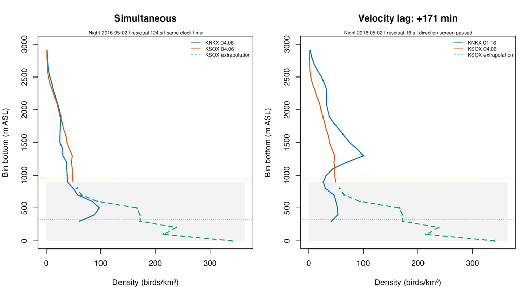

## Night of 2018-05-04

KNKX movement: **9.8 m/s toward 327°**. KSOX: **11.6 m/s toward 327°**. Lag: **178 minutes**, with **KNKX first**.

The simultaneous pairing supplied the upper-layer match used to select this example.

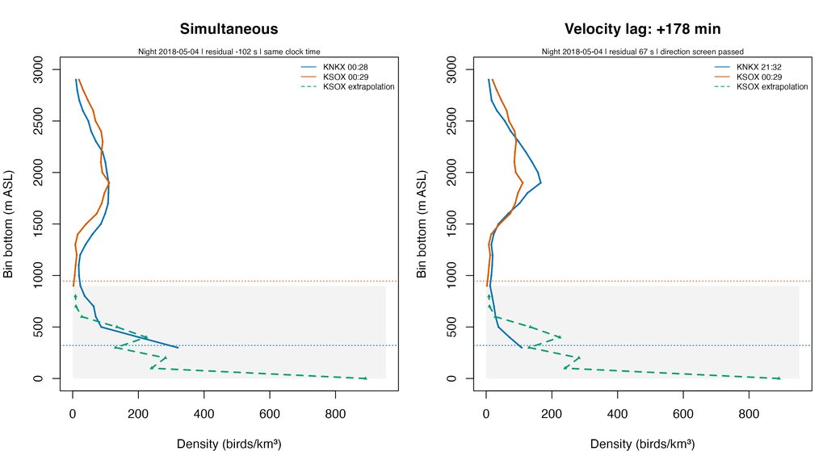

## Night of 2016-05-01

KNKX movement: **12.7 m/s toward 306°**. KSOX: **10.9 m/s toward 313°**. Lag: **174 minutes**, with **KNKX first**.

The simultaneous pairing supplied the upper-layer match used to select this example.

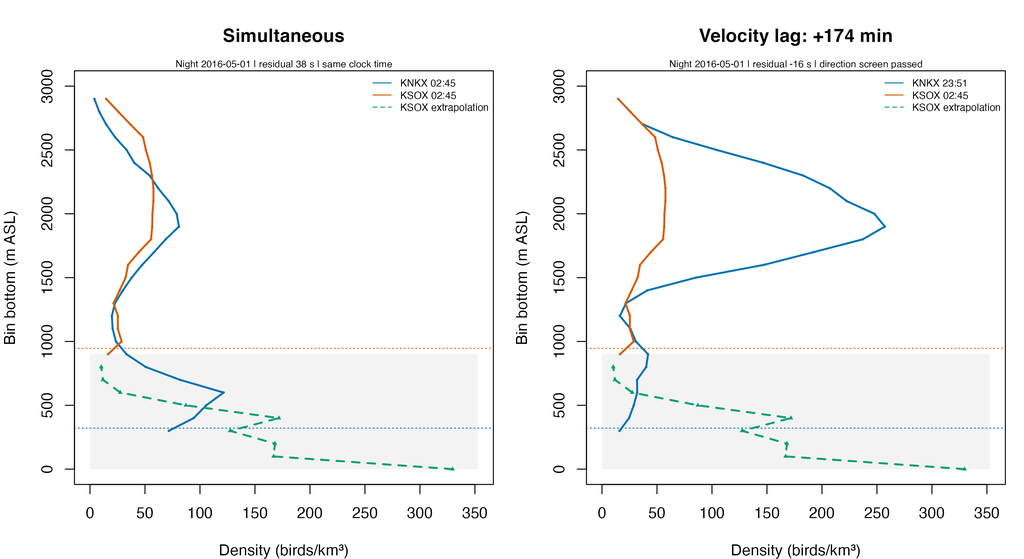

# Fall

## Night of 2025-08-28

KNKX movement: **13.7 m/s toward 137°**. KSOX: **10.7 m/s toward 137°**. Lag: **161 minutes**, with **KSOX first**.

The velocity lag pairing supplied the upper-layer match used to select this example.

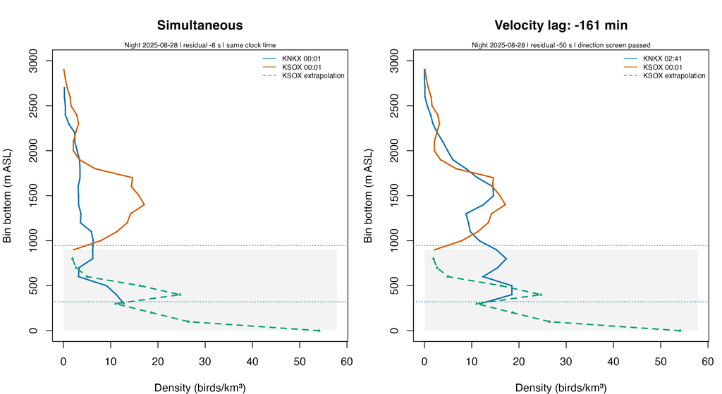

## Night of 2017-10-01

KNKX movement: **15.6 m/s toward 131°**. KSOX: **17.2 m/s toward 136°**. Lag: **122 minutes**, with **KSOX first**.

The simultaneous pairing supplied the upper-layer match used to select this example.

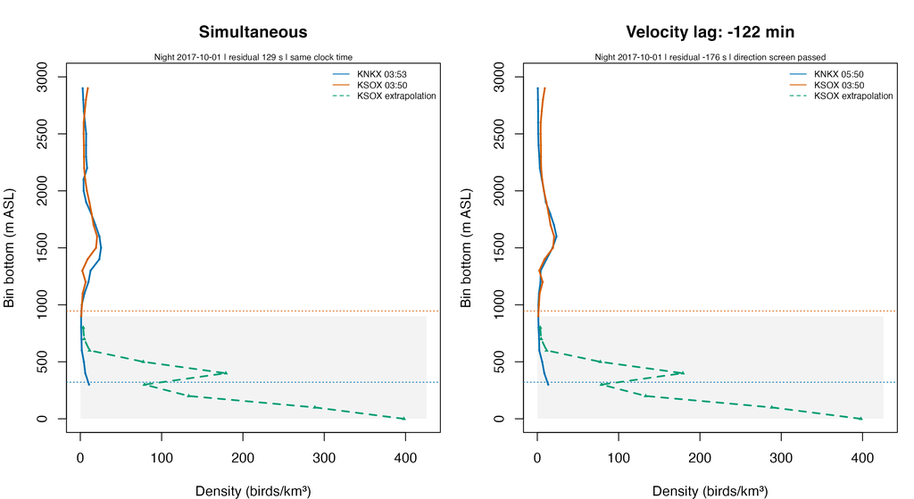

## Night of 2014-10-05

KNKX movement: **9.5 m/s toward 152°**. KSOX: **8.3 m/s toward 160°**. Lag: **215 minutes**, with **KSOX first**.

The velocity lag pairing supplied the upper-layer match used to select this example.

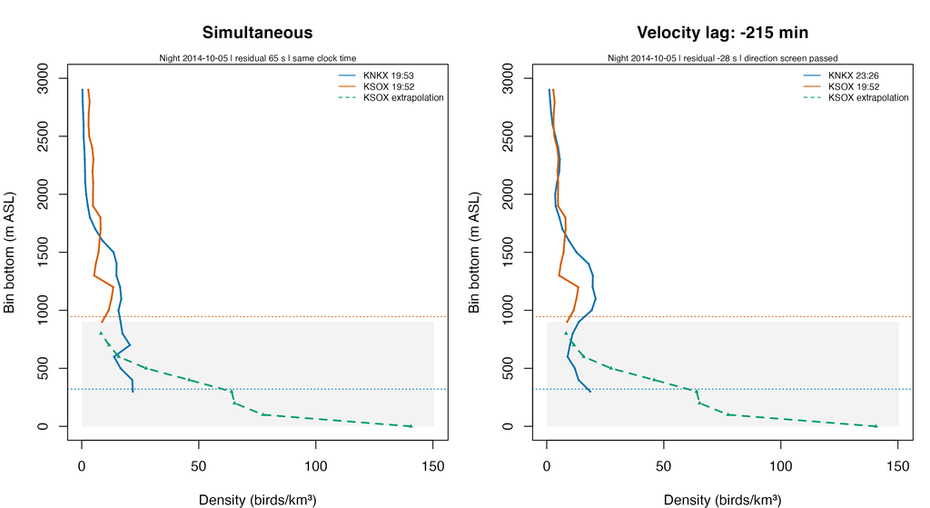

Reproduce locally with `Rscript analysis/knkx-ksox/render.R`. The RMarkdown, R plots, model predictions, matched timestamps, and source records are in this directory.